# Assignment 1: Data set selection and initial Processing.

Wei Jin Luo

2025-02-10

## Introduction to Data

The dataset that I will process is GSE195585 and it is associated with this [paper](https://pmc.ncbi.nlm.nih.gov/articles/PMC9037237/#s3)(Centner C 2022)

The paper investigates the effects of collagen peptides (CP) combined with high-load resistance exercise on gene expression related to muscle protein synthesis. The study involved 30 participants who were randomized to perform leg extension exercises with either CP or a placebo and muscle biopsies were taken at various time points to analyze gene expression.

## Installing necessary packages

```r
if (!require("BiocManager", quietly = TRUE))
    install.packages("BiocManager")

if (!require("GEOquery", quietly = TRUE))
    BiocManager::install("GEOquery")

if (!require("edgeR", quietly = TRUE))
    BiocManager::install("edgeR")

if (!require("biomaRt", quietly = TRUE))
    BiocManager::install("biomaRt")

if (!require("knitr", quietly = TRUE))
    install.packages("knitr")

library(GEOquery)
library(edgeR)
library(biomaRt)
library(knitr)
```

#### Downloading the data

```r
# Define the GEO accession number
geo_accession <- "GSE195585"

# Define the file path to save the downloaded data
file_path <- paste0(geo_accession, "_data.RData")

# Check if the file already exists
if (file.exists(file_path)) {
  # Load the saved data
  load(file_path)
} else {
  # Download the dataset
  gse <- getGEO(geo_accession, GSEMatrix = TRUE)
  expr_data <- exprs(gse[[1]])

  # Save the downloaded data
  save(gse, expr_data, file = file_path)
}

# Download the supplementary file
download_dir <- file.path(getwd(), "data")
dir.create(download_dir)

# Check if the data has already been downloaded
if (!file.exists(file.path(download_dir, geo_accession))) {
  getGEOSuppFiles(
    geo_accession,
    baseDir = download_dir,
    fetch_files = TRUE
  )


  # Once the data has been download we can unpack some of the data
  untar(file.path(download_dir, geo_accession, 'GSE195585_RAW.tar'), exdir = file.path(download_dir, geo_accession))
}
```

After the data has been unpacked, I noticed that the gene expression data for each sample are in their own separate files, thus I will first need to combine the expression data from each sample into a single dataframe for analysis. Additionally, there is a lot of data from the paper since gene expression data was measured across multiple timepoints. For this assignment I will use the data from a single timepoint (4h) as suggested by Prof. Isserlin.

```r
# Extract hour 4 data
raw_count_files <- list.files(
  path = file.path(download_dir, geo_accession),
  pattern = "_4h_.*raw_counts.txt.gz", # Include "_4h_" in the pattern
  full.names = TRUE
)

# Load the dataset into 1 dataframe
combine_raw_counts <- function(file_list) {
  combined_df <- NULL

  for (file in file_list) {
    df <- read.table(gzfile(file), header = TRUE, sep = "\t")

    if (is.null(combined_df)) {
      combined_df <- df
    } else {
      combined_df <- merge(combined_df, df, by = "ENTREZID", all = TRUE)
    }
  }

  return(combined_df)
}

# Combined dataframe with all the data
combined_df <- combine_raw_counts(raw_count_files)
# Sort the columns for easier reading
sorted_columns <- c("ENTREZID", sort(grep("Placebo", colnames(combined_df), value = TRUE)), sort(grep("Verum", colnames(combined_df), value = TRUE)))
inital_df <- combined_df[, sorted_columns]

head(inital_df)
```

```
##             ENTREZID Placebo_4h_10c Placebo_4h_12c Placebo_4h_14c
## 1 ENSG00000000003.15       65.12685       48.03290       75.65844
## 2  ENSG00000000005.6        0.00000        2.00000       44.00000
## 3 ENSG00000000419.12      363.00007      327.99980      473.99960
## 4 ENSG00000000457.14      133.01215      116.95020      142.81464
## 5 ENSG00000000460.17        6.28953        3.04975        6.18534
## 6 ENSG00000000938.13       15.99999       12.00000       38.00004
##   Placebo_4h_16c Placebo_4h_19c Placebo_4h_1c Placebo_4h_20c Placebo_4h_21c
## 1      62.839750       65.02506      64.43553       38.08740       46.93069
## 2       0.000000        2.00000       0.00000        1.00000        0.00000
## 3     342.000030      380.00010     434.99998      352.00003      323.99964
## 4      94.287600      106.74639     124.81018       88.61669       92.99997
## 5       5.712444       15.25357       7.13375        5.93090        3.00000
## 6      23.999990       29.99999      19.00001       47.00001       21.00000
##   Placebo_4h_24c Placebo_4h_27c Placebo_4h_28c Placebo_4h_2c Placebo_4h_30c
```

[output cut: 27 more lines]

## Mapping Gene IDs to HUGO symbols

First lets check to ensure that there are no NA values or any duplicated genes

```r
# Any NA values should return FALSE
anyNA(inital_df)
```

```
## [1] FALSE
```

```r
# Any duplicated Genes should return 0
sum(duplicated(rownames(inital_df)))
```

```
## [1] 0
```

Now lets map the gene Ids to HUGO symbols by using the `biomaRt` package.

```r
mart <- useMart("ensembl", dataset = "hsapiens_gene_ensembl")
ensembl <- biomaRt::useEnsembl(biomart = "ensembl", dataset = "hsapiens_gene_ensembl")

entrez_ids <- inital_df$ENTREZID
cleaned_ids <- gsub("\\..*", "", entrez_ids)
gene_mapping <- biomaRt::getBM(
  attributes = c("ensembl_gene_id", "external_gene_name"),
  filters = "ensembl_gene_id",
  values = cleaned_ids,
  mart = ensembl
)
head(gene_mapping)
```

```
##   ensembl_gene_id external_gene_name
## 1 ENSG00000000003             TSPAN6
## 2 ENSG00000000005               TNMD
## 3 ENSG00000000419               DPM1
## 4 ENSG00000000457              SCYL3
## 5 ENSG00000000460              FIRRM
## 6 ENSG00000000938                FGR
```

```r
# Adding HUGO symbols to our dataframe
inital_df$HUGO <- cleaned_ids
inital_df$HUGO <- gene_mapping$external_gene_name[match(cleaned_ids, gene_mapping$ensembl_gene_id)]

hugo_symbols_df <- inital_df[, c("ENTREZID", "HUGO", setdiff(names(inital_df), c("ENTREZID", "HUGO")))]
head(hugo_symbols_df)
```

```
##             ENTREZID   HUGO Placebo_4h_10c Placebo_4h_12c Placebo_4h_14c
## 1 ENSG00000000003.15 TSPAN6       65.12685       48.03290       75.65844
## 2  ENSG00000000005.6   TNMD        0.00000        2.00000       44.00000
## 3 ENSG00000000419.12   DPM1      363.00007      327.99980      473.99960
## 4 ENSG00000000457.14  SCYL3      133.01215      116.95020      142.81464
## 5 ENSG00000000460.17  FIRRM        6.28953        3.04975        6.18534
## 6 ENSG00000000938.13    FGR       15.99999       12.00000       38.00004
##   Placebo_4h_16c Placebo_4h_19c Placebo_4h_1c Placebo_4h_20c Placebo_4h_21c
## 1      62.839750       65.02506      64.43553       38.08740       46.93069
## 2       0.000000        2.00000       0.00000        1.00000        0.00000
## 3     342.000030      380.00010     434.99998      352.00003      323.99964
## 4      94.287600      106.74639     124.81018       88.61669       92.99997
## 5       5.712444       15.25357       7.13375        5.93090        3.00000
## 6      23.999990       29.99999      19.00001       47.00001       21.00000
##   Placebo_4h_24c Placebo_4h_27c Placebo_4h_28c Placebo_4h_2c Placebo_4h_30c
```

[output cut: 27 more lines]

## NA HUGO symbols

First lets take a look at some of the potential issues that we have to handle in the data

```r
# Check for any NA HUGO symbols
na_symbols <- sum(is.na(hugo_symbols_df$HUGO))
na_symbols
```

```
## [1] 1297
```

Since we only have a small amount of NA gene symbols, we can remove them without it affected the overall analysis too much

```r
# Remove NA genes
hugo_symbols_df <- hugo_symbols_df[!is.na(hugo_symbols_df$HUGO), ]
sum(is.na(hugo_symbols_df$HUGO))
```

```
## [1] 0
```

## No expression

We can also remove rows that have no expression across all samples

```r
expression_columns <- colnames(hugo_symbols_df)[!colnames(hugo_symbols_df) %in% c("ENTREZID", "HUGO")]
nrow(hugo_symbols_df[rowSums(hugo_symbols_df[expression_columns] != 0) == 0, ])
```

```
## [1] 18785
```

```r
hugo_symbols_df <- hugo_symbols_df[!(rowSums(hugo_symbols_df[expression_columns] != 0) == 0), ]
```

## Empty Gene Symbols

Next we will handle the empty gene symbols

```r
# Empty gene symbols:
sum(hugo_symbols_df$HUGO == "")
```

```
## [1] 10794
```

There is quite a bit of empty gene symbols 10794, I don’t want to remove them since this will affect the data. Since I will not be removing these empty gene symbols I will use the gene id in place of a HUGO symbol thus my final dataset produced **will NOT be according to the exact specifications in the assignment requirements**.

## Handling Duplicate Gene Symbols

Since empty gene symbols will also be counted as duplicated, we will temporarily remove them to handle to duplicates with actual HUGO symbols

```r
# Removed empty gene symbols
no_blanks <- hugo_symbols_df[!hugo_symbols_df$HUGO == "", ]
```

Now we can investigate some of the duplicates

```r
# Dealing with duplicates:
duplicated_hugo <- unique(no_blanks$HUGO[duplicated(no_blanks$HUGO)])
length(duplicated_hugo)
```

```
## [1] 42
```

```r
# Investigate some of the duplicates
head(no_blanks[no_blanks$HUGO == 'Y_RNA', ])
```

```
##                ENTREZID  HUGO Placebo_4h_10c Placebo_4h_12c Placebo_4h_14c
## 18062 ENSG00000199285.1 Y_RNA              0              0              0
## 18084 ENSG00000199331.1 Y_RNA              0              0              0
## 18085 ENSG00000199332.1 Y_RNA              0              0              0
## 18091 ENSG00000199349.1 Y_RNA              0              0              0
## 18098 ENSG00000199362.1 Y_RNA              0              0              0
## 18120 ENSG00000199409.1 Y_RNA              0              0              0
##       Placebo_4h_16c Placebo_4h_19c Placebo_4h_1c Placebo_4h_20c Placebo_4h_21c
## 18062              0              0             0              0              0
## 18084              0              1             0              0              1
## 18085              0              0             0              0              0
## 18091              0              0             0              0              0
## 18098              0              0             0              0              0
## 18120              0              1             0              0              0
##       Placebo_4h_24c Placebo_4h_27c Placebo_4h_28c Placebo_4h_2c Placebo_4h_30c
```

[output cut: 34 more lines]

```r
head(no_blanks[no_blanks$HUGO == 'Metazoa_SRP', ])
```

```
##                ENTREZID        HUGO Placebo_4h_10c Placebo_4h_12c
## 17032 ENSG00000196274.5 Metazoa_SRP              0       0.000000
## 17374 ENSG00000197334.2 Metazoa_SRP              1       0.878889
## 19538 ENSG00000203286.5 Metazoa_SRP              0       0.000000
## 19558 ENSG00000203411.3 Metazoa_SRP              0       0.000000
## 19564 ENSG00000203436.2 Metazoa_SRP              0       0.000000
## 19586 ENSG00000203573.4 Metazoa_SRP              0       0.000000
##       Placebo_4h_14c Placebo_4h_16c Placebo_4h_19c Placebo_4h_1c Placebo_4h_20c
## 17032              0        0.00000              0             0       0.945802
## 17374              0        0.00000              0             0       0.000000
## 19538              0        0.00000              0             0       0.000000
## 19558              0        3.01414              0             0       0.000000
## 19564              0        0.00000              0             0       0.000000
## 19586              0        2.00000              0             0       0.000000
##       Placebo_4h_21c Placebo_4h_24c Placebo_4h_27c Placebo_4h_28c Placebo_4h_2c
```

[output cut: 34 more lines]

```r
head(no_blanks[no_blanks$HUGO == 'U3', ])
```

```
##                ENTREZID HUGO Placebo_4h_10c Placebo_4h_12c Placebo_4h_14c
## 18311 ENSG00000199856.2   U3            0.5              1              0
## 18687 ENSG00000200693.2   U3            1.0              2              1
## 18982 ENSG00000201368.2   U3            0.0              0              0
## 20813 ENSG00000207119.2   U3            0.0              1              0
## 21800 ENSG00000212182.2   U3            0.0              0              0
## 21960 ENSG00000212479.2   U3            0.0              0              0
##       Placebo_4h_16c Placebo_4h_19c Placebo_4h_1c Placebo_4h_20c Placebo_4h_21c
## 18311              0              0             0              0              0
## 18687              0              2             1              0              1
## 18982              0              0             0              1              0
## 20813              0              0             0              0              0
## 21800              0              0             0              0              0
## 21960              0              0             0              0              0
##       Placebo_4h_24c Placebo_4h_27c Placebo_4h_28c Placebo_4h_2c Placebo_4h_30c
```

[output cut: 34 more lines]

I noticed that for a lot of the duplicated HUGO symbols, much of the expression data in each column is 0, and since there is also only a small amount of duplicated genes compared to the total, I believe that it is ok to remove these duplicated HUGO symbols

```r
hugo_symbols_df <- hugo_symbols_df[!hugo_symbols_df$HUGO %in% duplicated_hugo, ]
```

Now since, we won’t remove all the blank gene symbols I add the gene ID in place of the HUGO symbol for those genes

```r
hugo_symbols_df$HUGO[hugo_symbols_df$HUGO == ""] <- hugo_symbols_df$ENTREZID[hugo_symbols_df$HUGO == ""]
```

## Removing Low Gene Counts

I filter by counts per million (CPM) and remove values that don’t have at least 1 cpm. Since we have 30 total samples 15 control and 15 CP supplemented, we will set the minimum threshold to at 1 cpm in at least 15 samples

```r
min_samples <- 15

# Exclude ENTREZID and HUGO columns
dataset_no_entrez_hugo <- as.matrix(hugo_symbols_df[, -c(1, 2)])
cpm_values <- edgeR::cpm(dataset_no_entrez_hugo)

sufficiently_expressed <- rowSums(cpm_values > 1) >= min_samples


# Final cleaned data
filtered_data <- hugo_symbols_df[sufficiently_expressed, ]
rownames(filtered_data) <- filtered_data$HUGO
final_dataset <- filtered_data[, -c(1, 2)]

# Also keep a low_counts_not_removed df for comparison
low_counts_not_removed <- hugo_symbols_df
rownames(low_counts_not_removed) <- low_counts_not_removed$HUGO
low_counts_not_removed <- low_counts_not_removed[, -c(1, 2)]
```

#### Normalization

Create a density plot

```r
create_density_plot <- function(dataset) {
  counts_density <- apply(log2(dataset), 2, density)

  #calculate the limits across all the samples
  xlim <- 0; ylim <- 0
  for (i in 1:length(counts_density)) {
    xlim <- range(c(xlim, counts_density[[i]]$x));
    ylim <- range(c(ylim, counts_density[[i]]$y))
  }
  cols <- rainbow(length(counts_density))
  ltys <- rep(1, length(counts_density))

  #plot the first density plot to initialize the plot
  plot(counts_density[[1]], xlim=xlim, ylim=ylim, type="n",
  ylab="Smoothing density of log2-CPM",
  main="", cex.lab = 0.85)

  #plot each line
  for (i in 1:length(counts_density)) {
    lines(counts_density[[i]], col=cols[i], lty=ltys[i])
  }

  #create legend
  legend("topright", colnames(dataset),
  col=cols, lty=ltys, cex=0.3,
  border ="blue", text.col = "green4",
  merge = TRUE, bg = "gray90")
}
```

First we can visualize the our density plot without the low count genes removed

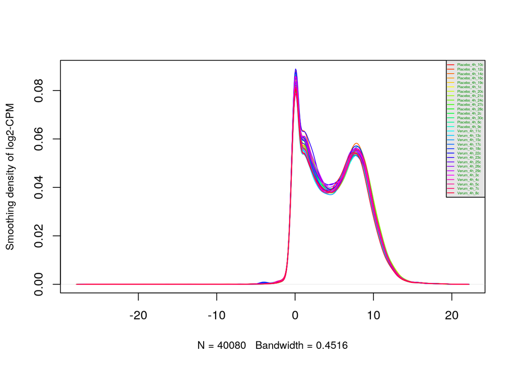

```r
create_density_plot(low_counts_not_removed)
```

Next we can visualize the density plot with the low counts removed

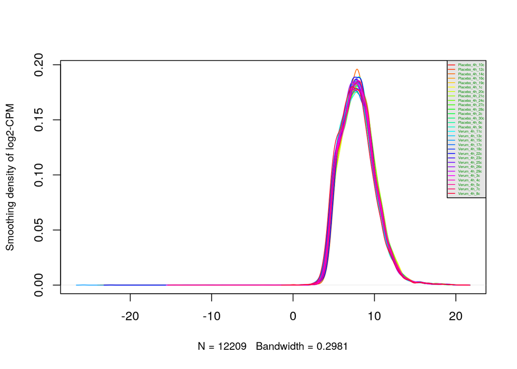

```r
create_density_plot(final_dataset)
```

Finally we will apply TMM normalization to our dataset

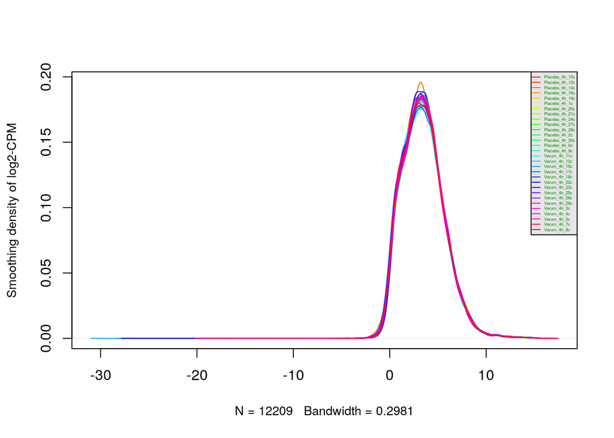

```r
# Apply normalization
d <- DGEList(counts = final_dataset)
d <- calcNormFactors(d)
normalized_counts <- cpm(d)

create_density_plot(normalized_counts)
```

## Interpret and Document Questions

**1. Why is the dataset of interest to you?**

This dataset caught my attention because I am deeply passionate about fitness. A highly debated topic within the fitness community is whether certain supplements genuinely have an effect or are merely placebos or gimmicks. This area requires more research, and I found this paper particularly intriguing. The results presented in this study are also quite interesting.

**2. What are the control and test conditions of the dataset?**

The control condition of the dataset is resistance training without collagen peptide (CP) supplementation and the test condition is resistance training with CP supplementation

**3. How many samples in each of the conditions of your dataset?**

There are 15 samples for the treatment group and 15 samples for the control

**4. Were there expression values that were not unique for specific genes? How did you handle these?**

There were a handful of duplicate gene symbols, however, much of the expression data in each column is 0, and since there is also only a small amount of duplicated genes compared to the total, I decided to remove the duplicate gene symbols

**5. Were there expression values that could not be mapped to current HUGO symbols?**

Yes, there were quite a few values that couldn’t be mapped to current HUGO symbols. Since there were so many I decided to keep those values in because removing them could possibly affect the results

**6. Were there any outliers in your dataset? How were they handled in the originating paper? How many outliers were removed?**

After cleaning and normalization, I didn’t handle any specific outliers, the original paper also doesn’t specifically mention how they handled any outliers

**7. How did you handle replicates?**

There were a few genes with multiple entries and since there were a small amount compared to the overall data, I removed them

**8. What is the final coverage of your dataset?**

The final coverage of my dataset had 12209 genes

## References

This analysis uses several R packages including `BiocManager` (Morgan and Ramos 2024), `GEOquery` (Davis and Meltzer 2007), `edgeR` (Chen et al. 2024), `biomaRt` (Durinck et al. 2005), and `knitr` (Xie 2024).

Centner C, Mallard A, Jerger S. 2022. “Supplementation of Specific Collagen Peptides Following High-Load Resistance Exercise Upregulates Gene Expression in Pathways Involved in Skeletal Muscle Signal Transduction.” *Front Physiol.* 13: 838004. https://doi.org/10.3389/fphys.2022.838004.

Chen, Yunshun, Lizhong Chen, Aaron T L Lun, Pedro Baldoni, and Gordon K Smyth. 2024. “edgeR 4.0: Powerful Differential Analysis of Sequencing Data with Expanded Functionality and Improved Support for Small Counts and Larger Datasets.” *bioRxiv*. https://doi.org/10.1101/2024.01.21.576131.

Davis, Sean, and Paul Meltzer. 2007. “GEOquery: A Bridge Between the Gene Expression Omnibus (GEO) and BioConductor.” *Bioinformatics* 14: 1846–47.

Durinck, Steffen, Yves Moreau, Arek Kasprzyk, Sean Davis, Bart De Moor, Alvis Brazma, and Wolfgang Huber. 2005. “BioMart and Bioconductor: A Powerful Link Between Biological Databases and Microarray Data Analysis.” *Bioinformatics* 21: 3439–40.

Morgan, Martin, and Marcel Ramos. 2024. *BiocManager: Access the Bioconductor Project Package Repository*. https://bioconductor.github.io/BiocManager/.

Xie, Yihui. 2024. *Knitr: A General-Purpose Package for Dynamic Report Generation in r*. https://yihui.org/knitr/.